# Chap6

**Chapter 9 linear mixed effects models for normal response: using** BPRS** data

```r
BPRSL<- read.csv ("bprs.csv", row.names = 1)
summary (BPRSL)
```

```
##    treatment      subject          weeks          bprs            week
##  Min.   :1.0   Min.   : 1.00   week0  : 40   Min.   :18.00   Min.   :0
##  1st Qu.:1.0   1st Qu.: 5.75   week1  : 40   1st Qu.:27.00   1st Qu.:2
##  Median :1.5   Median :10.50   week2  : 40   Median :35.00   Median :4
##  Mean   :1.5   Mean   :10.50   week3  : 40   Mean   :37.66   Mean   :4
##  3rd Qu.:2.0   3rd Qu.:15.25   week4  : 40   3rd Qu.:43.00   3rd Qu.:6
##  Max.   :2.0   Max.   :20.00   week5  : 40   Max.   :95.00   Max.   :8
##                                (Other):120
```

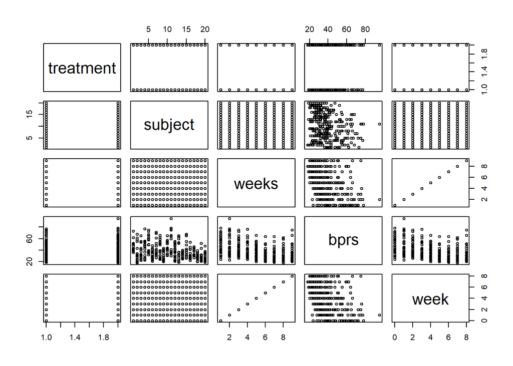

```r
pairs(BPRSL, cex=0.7)
```

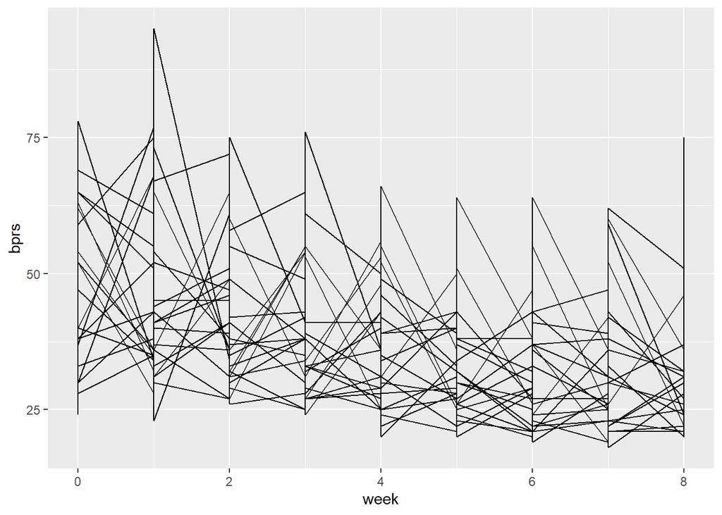

```r
ggplot(BPRSL, aes(x = week, y = bprs, group = subject)) +
  geom_line()
```

```r
BPRSL_reg <- lm(bprs ~ week + treatment, data = BPRSL)
summary(BPRSL_reg)
```

```
##
## Call:
## lm(formula = bprs ~ week + treatment, data = BPRSL)
##
## Residuals:
##     Min      1Q  Median      3Q     Max
## -22.454  -8.965  -3.196   7.002  50.244
##
## Coefficients:
##             Estimate Std. Error t value Pr(>|t|)
## (Intercept)  45.8817     2.2949  19.993   <2e-16 ***
## week         -2.2704     0.2524  -8.995   <2e-16 ***
## treatment     0.5722     1.3034   0.439    0.661
## ---
## Signif. codes:  0 '***' 0.001 '**' 0.01 '*' 0.05 '.' 0.1 ' ' 1
##
## Residual standard error: 12.37 on 357 degrees of freedom
## Multiple R-squared:  0.1851, Adjusted R-squared:  0.1806
## F-statistic: 40.55 on 2 and 357 DF,  p-value: < 2.2e-16
```

Look at assocition between Psychiatric rating scale and week treatment and method of treatment, in which coefficients of *week* = - 2.27, and *treatment* = 0.57. The BPRS score seems to be decreasing in both treatment groups, we are interested whether one treatment seems to be more efficient than the other one.

Look at P-value of treatment = 0.66, it seems methods of treatment does not effec to model

**** The Random Intercept Model

```r
library (lme4)
#Fit the random intercept model with the subject as the random effect
BPRSL_ref <- lmer(bprs ~ week + treatment + (1 | subject), data = BPRSL, REML = FALSE)
summary(BPRSL_ref)
```

```
## Linear mixed model fit by maximum likelihood  ['lmerMod']
## Formula: bprs ~ week + treatment + (1 | subject)
##    Data: BPRSL
##
##      AIC      BIC   logLik deviance df.resid
##   2748.7   2768.1  -1369.4   2738.7      355
##
## Scaled residuals:
##     Min      1Q  Median      3Q     Max
## -3.0481 -0.6749 -0.1361  0.4813  3.4855
##
## Random effects:
##  Groups   Name        Variance Std.Dev.
##  subject  (Intercept)  47.41    6.885
##  Residual             104.21   10.208
## Number of obs: 360, groups:  subject, 20
##
## Fixed effects:
##             Estimate Std. Error t value
## (Intercept)  45.8817     2.4413  18.794
## week         -2.2704     0.2084 -10.896
## treatment     0.5722     1.0761   0.532
##
## Correlation of Fixed Effects:
##           (Intr) week
## week      -0.341
## treatment -0.661  0.000
```

****Slippery slopes: Random Intercept and Random Slope Model

```r
# create a random intercept and random slope model
BPRSL_ref1 <- lmer(bprs ~ week + treatment + (week | subject), data = BPRSL, REML = FALSE)
summary(BPRSL_ref1)
```

```
## Linear mixed model fit by maximum likelihood  ['lmerMod']
## Formula: bprs ~ week + treatment + (week | subject)
##    Data: BPRSL
##
##      AIC      BIC   logLik deviance df.resid
##   2745.4   2772.6  -1365.7   2731.4      353
##
## Scaled residuals:
##     Min      1Q  Median      3Q     Max
## -2.8919 -0.6194 -0.0691  0.5531  3.7977
##
## Random effects:
##  Groups   Name        Variance Std.Dev. Corr
##  subject  (Intercept) 64.8222  8.0512
##           week         0.9609  0.9803   -0.51
##  Residual             97.4304  9.8707
## Number of obs: 360, groups:  subject, 20
##
## Fixed effects:
##             Estimate Std. Error t value
## (Intercept)  45.8817     2.5685  17.863
## week         -2.2704     0.2977  -7.626
## treatment     0.5722     1.0405   0.550
##
## Correlation of Fixed Effects:
##           (Intr) week
## week      -0.477
## treatment -0.608  0.000
```

```r
# perform an ANOVA test on the two models
anova(BPRSL_ref, BPRSL_ref1)
```

```
## Data: BPRSL
## Models:
## BPRSL_ref: bprs ~ week + treatment + (1 | subject)
## BPRSL_ref1: bprs ~ week + treatment + (week | subject)
##            Df    AIC    BIC  logLik deviance  Chisq Chi Df Pr(>Chisq)
## BPRSL_ref   5 2748.7 2768.1 -1369.4   2738.7
## BPRSL_ref1  7 2745.4 2772.6 -1365.7   2731.4 7.2721      2    0.02636 *
## ---
## Signif. codes:  0 '***' 0.001 '**' 0.01 '*' 0.05 '.' 0.1 ' ' 1
```